# Classification_supervisée

Tout d’abord, on filtre les lignes du dataframe pour ne conserver que celles où la variable depressif prend les valeurs “Oui” ou “Non”. Ensuite, on convertit toutes les variables du dataframe en facteurs, ce qui permet de traiter chaque colonne comme une variable catégorielle. Enfin on conserve que les colonnes spécifiées : ville_foyer, mange_a_ta_faim, alcool, Conflits.Familiaux, tiers_temps, niveau_etude, anxiété, suivi_psycho, diagnostic_episode_depressif, depressif et suivi_medicale_depressif. Ces variables ont été sélectionné après l’analyse du chisq2.

```r
sub_sante_mentale=read.csv("sante_mentale_regrouped.csv")
sub_sante_mentale <- sub_sante_mentale[sub_sante_mentale$depressif %in% c("Oui", "Non"), ]

# Convertir toutes les variables du dataframe en facteurs
for (column in names(sub_sante_mentale)) {
  sub_sante_mentale[[column]] <- as.factor(sub_sante_mentale[[column]])
}

# Subsetting the dataframe to keep only rows where depressif is "Oui" or "Non"
#sub_sante_mentale

# Assuming your data frame is named 'data'
sub_sante_mentale <- sub_sante_mentale[c("ville_foyer", "mange_a_ta_faim", "alcool", "Conflits.Familiaux",
                        "tiers_temps", "niveau_etude", "anxiété", "suivi_psycho",
                        "diagnostic_episode_depressif", "depressif", "suivi_medicale_depressif")]

#sub_sante_mentale
attach(sub_sante_mentale)
```

Ce code permet de diviser le jeu de données initial en deux parties : une pour l’entraînement du modèle (sub_sante_mentale.train) et une pour son évaluation (sub_sante_mentale.test).

```r
# Préparation des données
set.seed(1) # Permet de pouvoir reproduire les mêmes résultats
n <- nrow(sub_sante_mentale)
test.ratio <- 0.2 # Le taux de la db qu'on va utilisé comme test
n.test <- round(n * test.ratio) # Permet de savoir le nombre d'observation pour les test
tr <- sample(1:n, n.test)
sub_sante_mentale.test <- sub_sante_mentale[tr, ]
sub_sante_mentale.train <- sub_sante_mentale[-tr, ]
```

```r
# Examiner les valeurs uniques par groupe de 'depressif'
aggregate(sub_sante_mentale[], by=list(sub_sante_mentale$depressif), function(x) length(unique(x)))
```

| Group.1 | ville_foyer | mange_a_ta_faim | alcool | Conflits.Familiaux | tiers_temps | niveau_etude | anxiété | suivi_psycho | diagnostic_episode_depressif | depressif | suivi_medicale_depressif |
| --- | --- | --- | --- | --- | --- | --- | --- | --- | --- | --- | --- |
| Non | 8 | 2 | 6 | 3 | 2 | 3 | 3 | 2 | 3 | 1 | 2 |
| Oui | 8 | 2 | 4 | 3 | 2 | 2 | 3 | 2 | 3 | 1 | 2 |

```r
library(FactoMineR)
library(factoextra)
library(klaR)
library(MASS)
library(rpart)
library(rpart.plot)
library(pROC)
```

# LDA

```r
# Assuming all data issues are fixed
res_lda <- lda(depressif ~ ., data = sub_sante_mentale.train)
```

ROC lda

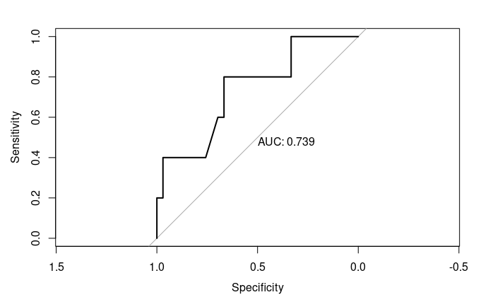

```r
#proba a posteriori de succes (dans la deuxième colonne) :
pred_lda <- predict(res_lda,newdata=sub_sante_mentale.test)

ROC_lda <- roc(sub_sante_mentale.test$depressif, pred_lda$posterior[,2] )
plot(ROC_lda, print.auc=TRUE,  print.auc.y = 0.5)
```

```r
ROC_lda$auc
```

```
Area under the curve: 0.7394
```

Accuracy Lda

```r
confusion_table_lda = table(Prédiction = pred_lda$class, Réalité = sub_sante_mentale.test$depressif)
confusion_table_lda
```

```
          Réalité
Prédiction Non Oui
       Non  29   3
       Oui   4   2
```

```r
accuracy_lda = mean(pred_lda$class == sub_sante_mentale.test$depressif)
accuracy_lda
```

```
[1] 0.8157895
```

# CART

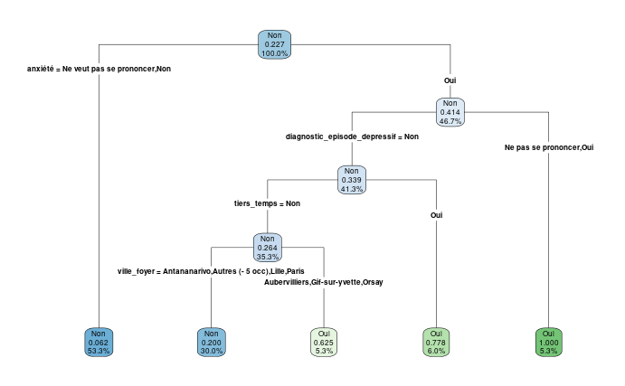

```r
library(rpart)
arbre.opt <- rpart(depressif~., data=sub_sante_mentale.train)
rpart.plot(arbre.opt, type=4, digits=3, roundint=FALSE)
```

ROC Cart

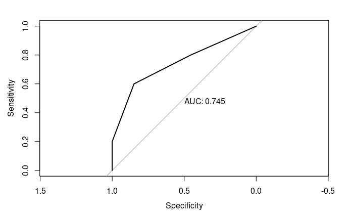

```r
# Courbe ROC pour CART
pred_cart <- predict(arbre.opt, sub_sante_mentale.test, type="prob")[,2]
ROC_cart <- roc(sub_sante_mentale.test$depressif, pred_cart)
plot(ROC_cart, print.auc=TRUE)
```

Accuracy Cart

```r
pred_cart_class = predict(arbre.opt, sub_sante_mentale.test, type="class")
confusion_table_cart = table(Prédiction = pred_cart_class, Réalité = sub_sante_mentale.test$depressif)
confusion_table_cart
```

```
          Réalité
Prédiction Non Oui
       Non  28   2
       Oui   5   3
```

```r
accuracy_cart = mean(pred_cart_class == sub_sante_mentale.test$depressif)
accuracy_cart
```

```
[1] 0.8157895
```

# Random Forest

```r
library(randomForest)
fit_RF <- randomForest(depressif~., data=sub_sante_mentale.train)
fit_RF
```

```
Call:
 randomForest(formula = depressif ~ ., data = sub_sante_mentale.train)
               Type of random forest: classification
                     Number of trees: 500
No. of variables tried at each split: 3

        OOB estimate of  error rate: 16.67%
Confusion matrix:
    Non Oui class.error
Non 114   2  0.01724138
Oui  23  11  0.67647059
```

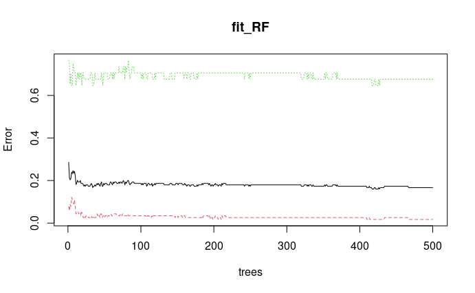

```r
plot(fit_RF)
```

C’est très écarté, nous allons donc les rassembler en utilisant la méthode suivante :

Ce code utilise SMOTE pour équilibrer les classes dans le jeu de données d’entraînement, et affiche la nouvelle répartition des classes pour vérifier l’efficacité de l’équilibrage

SMOTE (Synthetic Minority Over-sampling Technique) est une méthode utilisée pour traiter le déséquilibre des classes dans les jeux de données. Le déséquilibre des classes se produit lorsqu’une classe (la classe minoritaire) est sous-représentée par rapport aux autres classes (la classe majoritaire). Ce déséquilibre peut entraîner des modèles biaisés qui performent mal sur la classe minoritaire.

```r
library(DMwR)
data.train.balanced <- SMOTE(depressif~., sub_sante_mentale.train)
table(data.train.balanced$depressif)
```

```
Non Oui
136 102
```

```r
#data.train.balanced
```

Recalculons le tout avec la nouvelle base de donnée équilibrée par la méthode SMOTE

```r
fit_RF <- randomForest(depressif~.,data.train.balanced)
fit_RF
```

```
Call:
 randomForest(formula = depressif ~ ., data = data.train.balanced)
               Type of random forest: classification
                     Number of trees: 500
No. of variables tried at each split: 3

        OOB estimate of  error rate: 10.5%
Confusion matrix:
    Non Oui class.error
Non 129   7  0.05147059
Oui  18  84  0.17647059
```

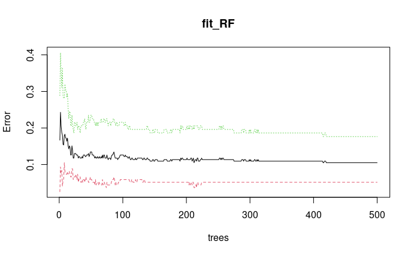

```r
plot(fit_RF)
```

Nous remarquons que c’est un peu mieux et que cela se rapproche plus.

ROC RandomForest

```r
## aire sous courbe ROC
pred_RF = predict(fit_RF, sub_sante_mentale.test, type="prob")[,2]
ROC_RF <- roc(sub_sante_mentale.test$depressif, pred_RF)
ROC_RF$auc
```

```
Area under the curve: 0.8303
```

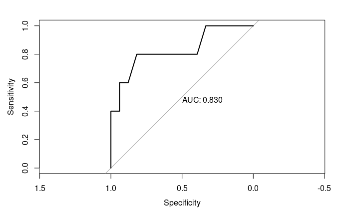

```r
plot(ROC_RF, print.auc=TRUE,  print.auc.y = 0.5)
```

Nous remarquons que nous obtenons une meilleure accuracy et une meilleur AUC avec la méthode random forest que par rapport aux deux autres. (LDA, CART) Accuracy RandomForest

```r
pred_RF_class = predict(fit_RF, sub_sante_mentale.test, type="class")
confusion_table_rf = table(Prédiction = pred_RF_class, Réalité = sub_sante_mentale.test$depressif)
confusion_table_rf
```

```
          Réalité
Prédiction Non Oui
       Non  29   2
       Oui   4   3
```

```r
accuracy_rf = mean(pred_RF_class == sub_sante_mentale.test$depressif)
accuracy_rf
```

```
[1] 0.8421053
```

# AdaBoost ————————————————————————–

```r
library(gbm)
library(ROCR)  # To perform ROC analysis
```

Ici nous appliquons donc adaboost à la base de donnée. Nous faisons exprès de mettre en valeur numérique pour adaboost

```r
fit.adaboost=gbm(as.numeric(depressif)-1 ~., sub_sante_mentale.train, distribution = "adaboost")
# au lieu de réouvrir le jeu de données, on utilise depressif en tant que variable qualitative, mais on la transforme en variable quantitative prenant les valeurs 0 et 1.
# vous pouvez vérifier ce que fait :
  #  as.numeric(data.train$DIFF)
  #  as.numeric(data.train$DIFF) -1
fit.adaboost
```

```
gbm(formula = as.numeric(depressif) - 1 ~ ., distribution = "adaboost",
    data = sub_sante_mentale.train)
A gradient boosted model with adaboost loss function.
100 iterations were performed.
There were 10 predictors of which 7 had non-zero influence.
```

Les commandes fournies ajustent un modèle de Gradient Boosting Machine (GBM) en utilisant l’algorithme AdaBoost sur le jeu de données sub_sante_mentale.train, avec la variable cible depressif convertie en format numérique. On ajuste donc le modèle en utilisant la validation croisée à 5 plis pour évaluer la performance sur différents nombres d’arbres (jusqu’à 3000) tout en appliquant un taux d’apprentissage (shrinkage) de 0,01. L’objectif de ce processus est d’optimiser le nombre d’arbres (B.opt) pour l’algorithme AdaBoost en identifiant le point où l’erreur de validation croisée est minimisée.

```
[1] 122
```

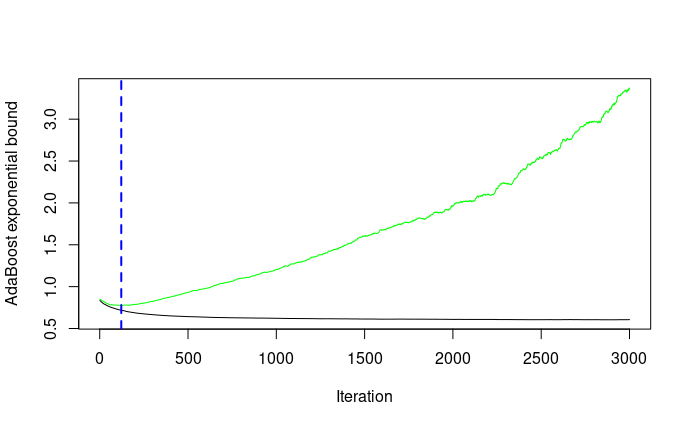

```r
### Calibrer B=n.tree par cross-validation :
fit.adaboost=gbm(as.numeric(depressif)-1 ~., sub_sante_mentale.train, distribution = "adaboost",cv.folds = 5, shrinkage = 0.01, n.trees=3000)
gbm.perf(fit.adaboost)
```

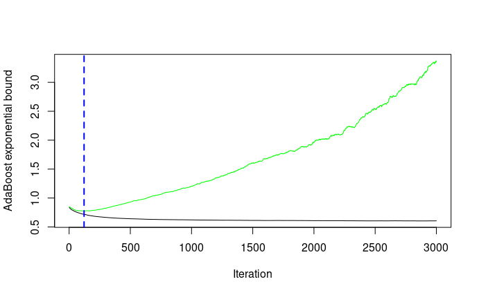

```r
B.opt = gbm.perf(fit.adaboost, method="cv")
```

La courbe montre que le modèle GBM atteint la meilleure performance sur l’ensemble de validation à environ 100 itérations. Au-delà de ce point, ajouter plus d’arbres conduit à un surapprentissage, comme l’indique l’augmentation de l’erreur de validation croisée.

Réappliquons alors l’adaboost en prenant en compte le nombre d’arbre B.opt

```r
## prédiction :
pred_adaboost = predict(fit.adaboost, newdata=sub_sante_mentale.test, type = "response", n.trees = B.opt)

# Pour le transformer en class :
class_adaboost = 1 * (pred_adaboost > 1/2)
```

Accuracy Adaboost

```r
confusion_table_adaboost = table(Prédiction = class_adaboost, Réalité = sub_sante_mentale.test$depressif)
confusion_table_adaboost
```

```
          Réalité
Prédiction Non Oui
         0  33   5
```

```r
accuracy_adaboost = mean(class_adaboost == sub_sante_mentale.test$depressif)
accuracy_adaboost
```

```
[1] 0
```

ROC Adaboost

```r
## aire sous courbe ROC
ROC_adaboost <- roc(sub_sante_mentale.test$depressif, pred_adaboost)
ROC_adaboost$auc
```

```
Area under the curve: 0.7182
```

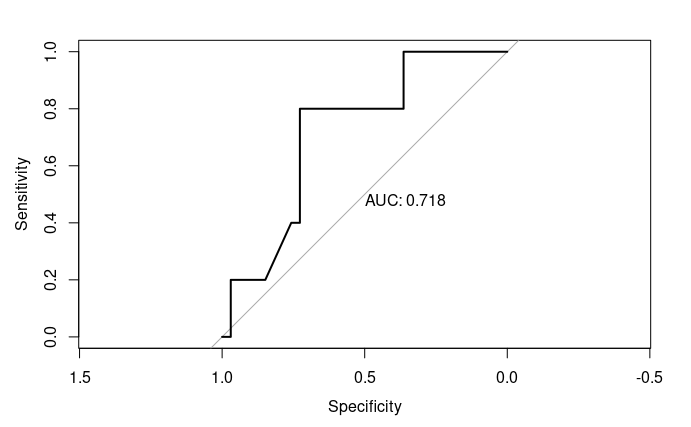

```r
plot(ROC_adaboost, print.auc=TRUE,  print.auc.y = 0.5)
```

# Comparaison des modèles

```r
# Comparaison --------------------------------------------------------------
result=matrix(NA, ncol=4, nrow=2)
rownames(result)=c('accuracy', 'AUC')
colnames(result)=c('lda', 'cart', 'RF', "adaboost")
result[1,]= c(accuracy_lda, accuracy_cart, accuracy_rf,accuracy_adaboost)
result[2,]=c(ROC_lda$auc, ROC_cart$auc, ROC_RF$auc,  ROC_adaboost$auc)
result
```

```
               lda      cart        RF  adaboost
accuracy 0.8157895 0.8157895 0.8421053 0.0000000
AUC      0.7393939 0.7454545 0.8303030 0.7181818
```

```r
apply(result,1, which.max )
```

```
accuracy      AUC
       3        3
```

```r
plot(ROC_lda, xlim=c(1,0))
plot(ROC_cart, add=TRUE, col=2)
```

```r
plot(ROC_RF, add=TRUE, col=3)
plot(ROC_adaboost, add=TRUE, col=4)
```

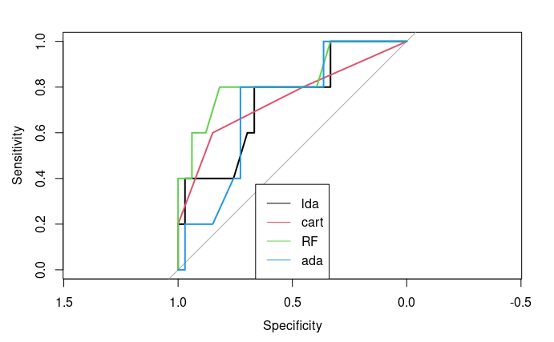

```r
legend('bottom', col=1:4, paste(c('lda', 'cart', 'RF', "ada")),  lwd=1)
```